# Online News Popularity

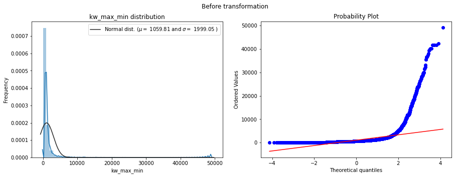

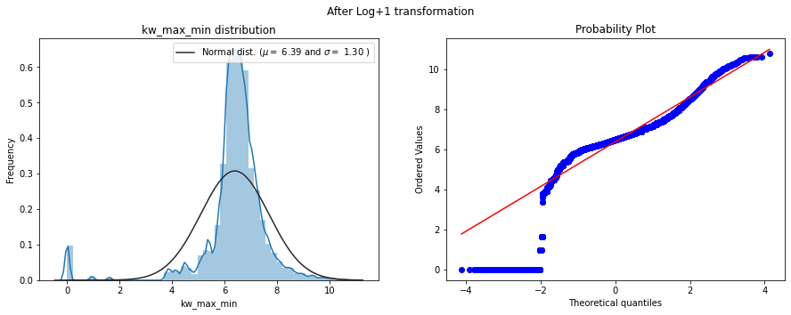

```python
transform('kw_max_min', 'Log+1')
```

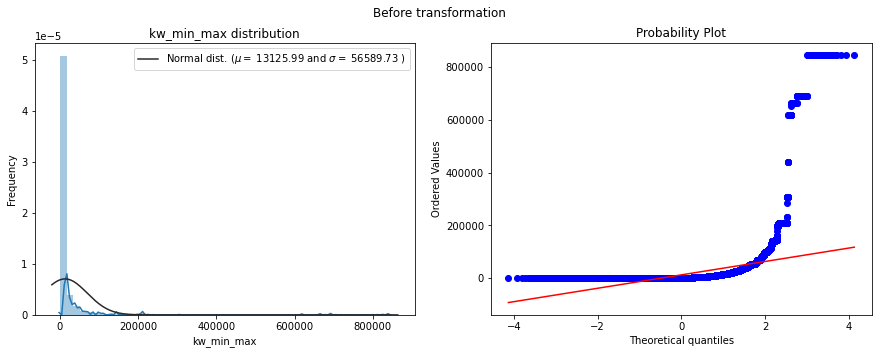

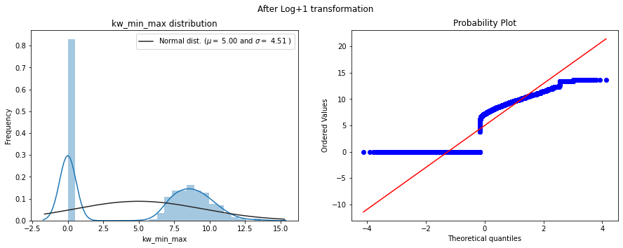

```python
transform('kw_min_max', 'Log+1')
```

```
C:\Program Files (x86)\WPy64-3850\python-3.8.5.amd64\lib\site-packages\seaborn\distributions.py:369: UserWarning: Default bandwidth for data is 0; skipping density estimation.
  warnings.warn(msg, UserWarning)
C:\Program Files (x86)\WPy64-3850\python-3.8.5.amd64\lib\site-packages\seaborn\distributions.py:369: UserWarning: Default bandwidth for data is 0; skipping density estimation.
  warnings.warn(msg, UserWarning)
```

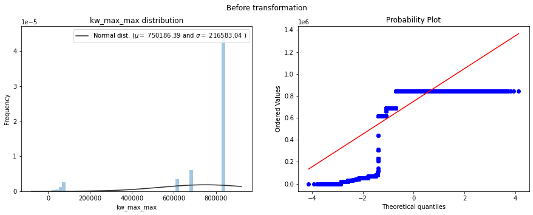

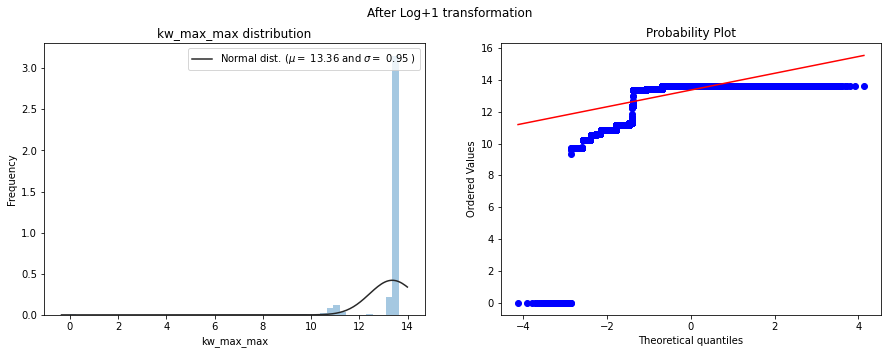

```python
transform('kw_max_max', 'Log+1')
```

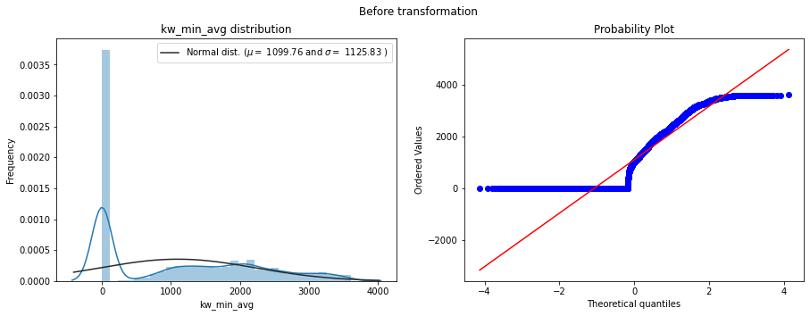

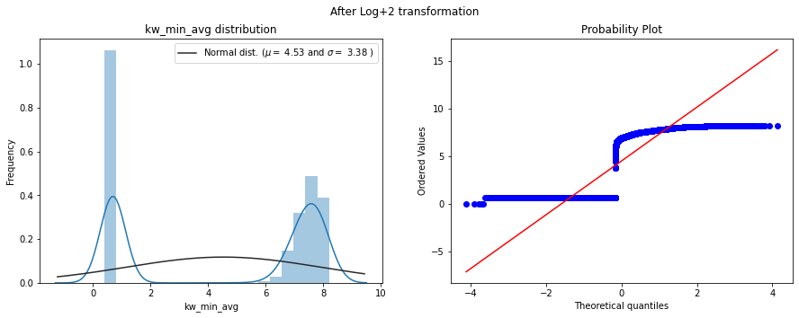

```python
transform('kw_min_avg', 'Log+2')
```

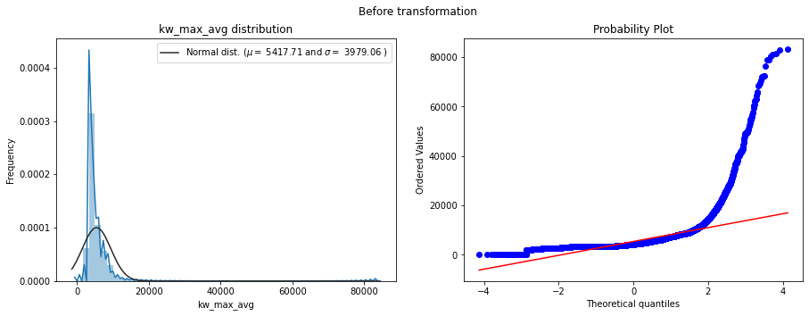

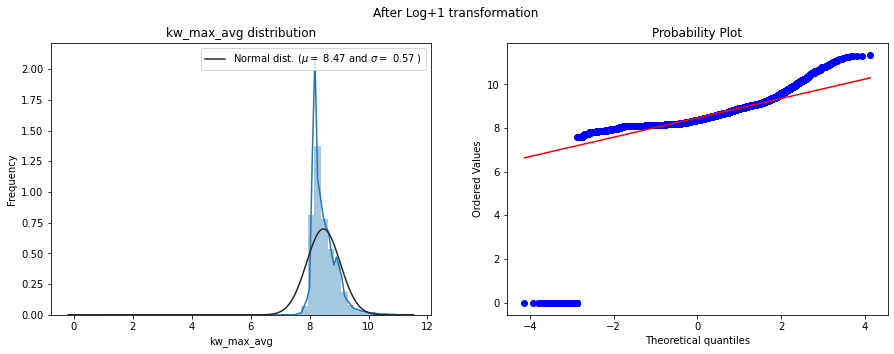

```python
transform('kw_max_avg', 'Log+1')
```

Most of the P-P plots are disfigured. This can be the consequence of a poor variable defintion or the persistence of outliers but only applied to the *keywords* attributes.

### Transforming the features *self_reference*

Let's examine the features *self_reference_min_shares*, *self_reference_max_shares* and *self_reference_avg_shares*.

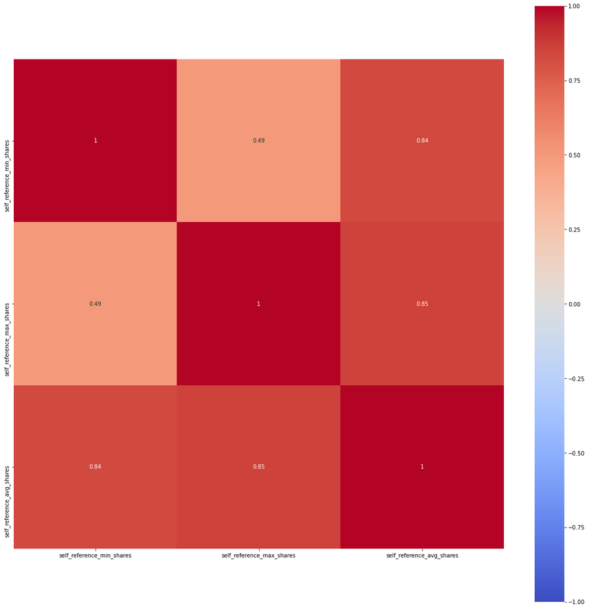

```python
corrplot(['self_reference_min_shares', 'self_reference_max_shares', 'self_reference_avg_shares'])
```

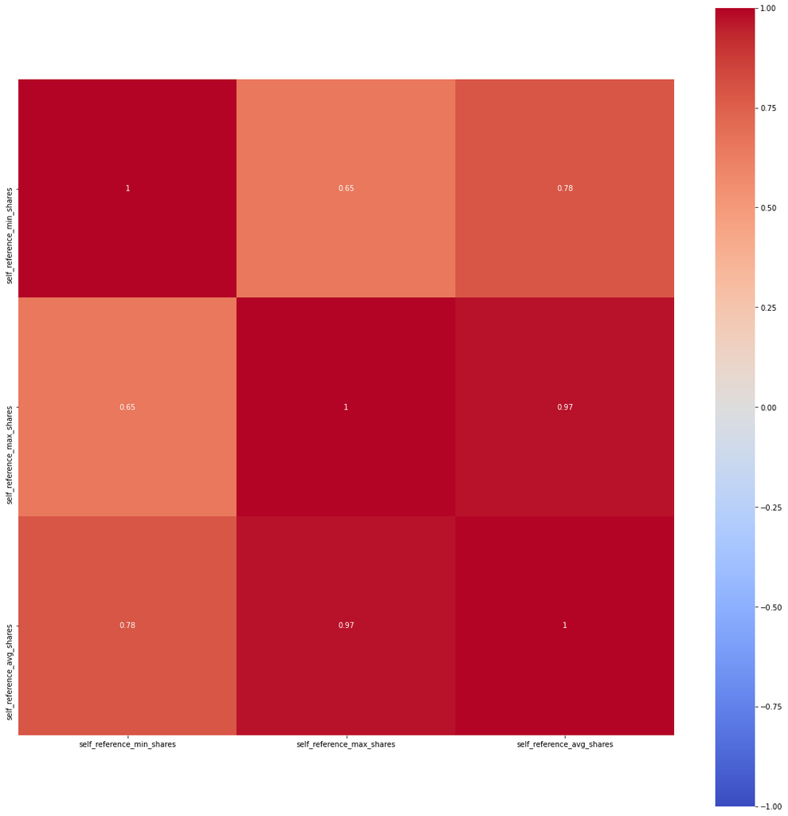

```python
corrplot(['self_reference_min_shares', 'self_reference_max_shares', 'self_reference_avg_shares'], 'spearman')
```

For the same reasons as before, we'll remove the *self_reference_avg_shares* feature.

```python
data = data.drop('self_reference_avg_shares', 1)
```

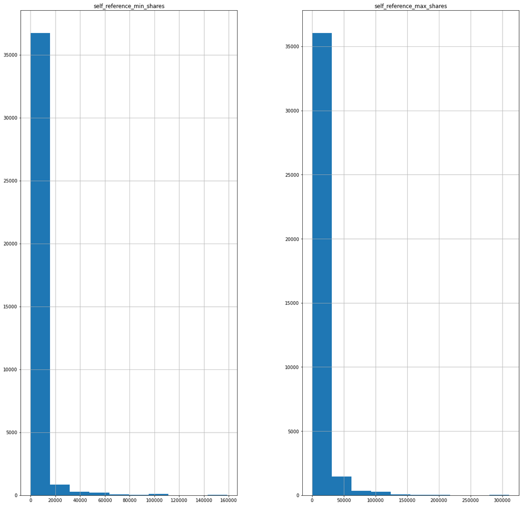

```python
hist(['self_reference_min_shares', 'self_reference_max_shares'])
```

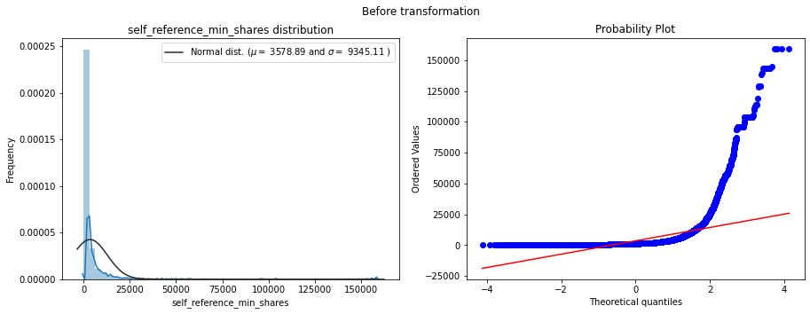

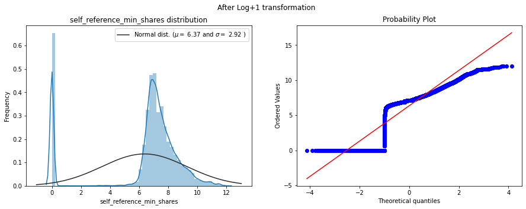

```python
transform('self_reference_min_shares', 'Log+1')
```

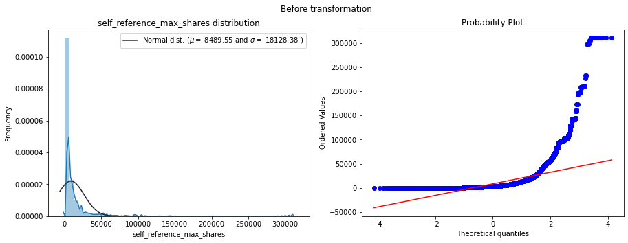

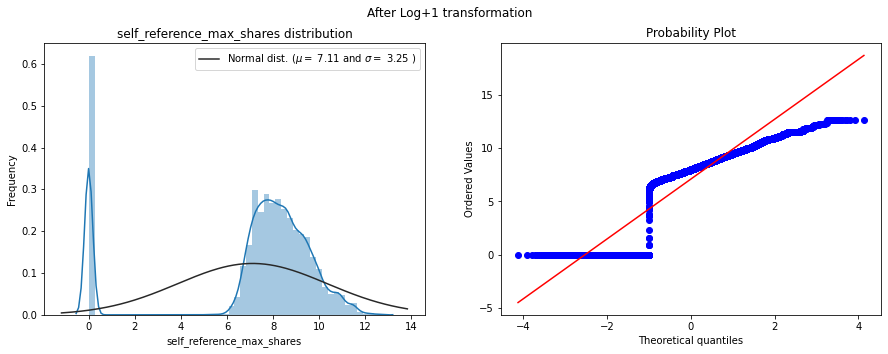

```python
transform('self_reference_max_shares', 'Log+1')
```

### Transforming the features *data_channel*

Unfortunately, the *data_channel* features are not all present. Indeed, we can see that some articles are classified under none of the categories :

```python
data[data['data_channel_is_lifestyle'] + data['data_channel_is_entertainment'] + data['data_channel_is_bus'] +
       data['data_channel_is_socmed'] + data['data_channel_is_tech'] + data['data_channel_is_world'] != 1][[
    'data_channel_is_lifestyle', 'data_channel_is_entertainment', 'data_channel_is_bus',
    'data_channel_is_socmed', 'data_channel_is_tech', 'data_channel_is_world']]
```

|  | data_channel_is_lifestyle | data_channel_is_entertainment | data_channel_is_bus | data_channel_is_socmed | data_channel_is_tech | data_channel_is_world |
| --- | --- | --- | --- | --- | --- | --- |
| 12 | 0.0 | 0.0 | 0.0 | 0.0 | 0.0 | 0.0 |
| 13 | 0.0 | 0.0 | 0.0 | 0.0 | 0.0 | 0.0 |
| 14 | 0.0 | 0.0 | 0.0 | 0.0 | 0.0 | 0.0 |
| 16 | 0.0 | 0.0 | 0.0 | 0.0 | 0.0 | 0.0 |
| 33 | 0.0 | 0.0 | 0.0 | 0.0 | 0.0 | 0.0 |
| ... | ... | ... | ... | ... | ... | ... |
| 39588 | 0.0 | 0.0 | 0.0 | 0.0 | 0.0 | 0.0 |
| 39607 | 0.0 | 0.0 | 0.0 | 0.0 | 0.0 | 0.0 |
| 39621 | 0.0 | 0.0 | 0.0 | 0.0 | 0.0 | 0.0 |
| 39634 | 0.0 | 0.0 | 0.0 | 0.0 | 0.0 | 0.0 |
| 39641 | 0.0 | 0.0 | 0.0 | 0.0 | 0.0 | 0.0 |

5450 rows × 6 columns

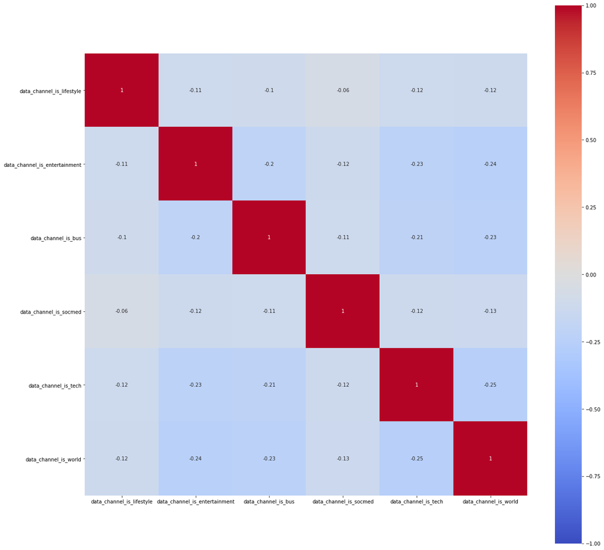

```python
corrplot(['data_channel_is_lifestyle', 'data_channel_is_entertainment', 'data_channel_is_bus',
       'data_channel_is_socmed', 'data_channel_is_tech', 'data_channel_is_world'])
```

Evidently, all features are negatively correlated to each other, but there are no real $y = -x$ relations. We shall restrain ourselves to transform these features.

### Transforming the features *weekday* and *is_weekend*

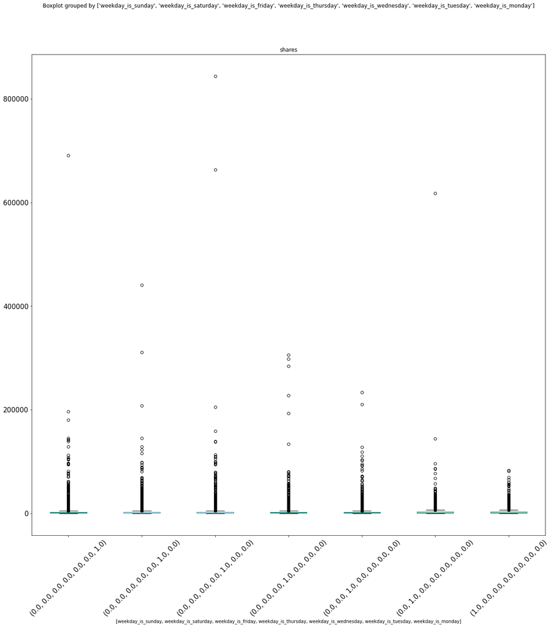

```python
box = data.boxplot(column=['shares'], by=['weekday_is_sunday', 'weekday_is_saturday', 'weekday_is_friday',
                                         'weekday_is_thursday', 'weekday_is_wednesday', 'weekday_is_tuesday',
                                         'weekday_is_monday'], return_type = None, grid = False, rot = 45, fontsize = 15)
```

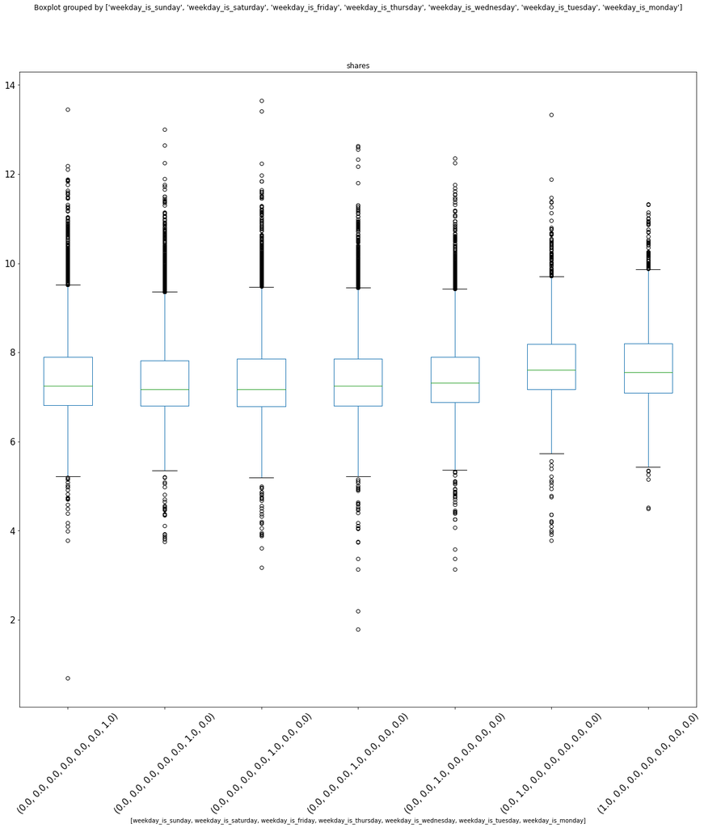

```python
datalog10 = data.copy()
datalog10.shares = np.log1p(datalog10.shares)
datalog10.boxplot(column=['shares'], by=['weekday_is_sunday', 'weekday_is_saturday', 'weekday_is_friday',
                                         'weekday_is_thursday', 'weekday_is_wednesday', 'weekday_is_tuesday',
                                         'weekday_is_monday'], return_type = None, grid = False, rot = 45, fontsize = 15)
```

```python
data = data.drop(['weekday_is_sunday', 'is_weekend'], 1)
```

### Transforming the features *LDA*

The Latent Dirichlet allocation (LDA) is a statistical method that allows the "gentrification" of the individuals following different topics. Here we suppose that every article is described by its "allegiance" to 5 different topics. These topics are mathematically established. A more known example in the academic field would be the Principal Component Analysis, which constructs artificial variables that suffice to explain the dataset, most of the time, the PCA reveals that most of the variance is explained by fewer number of variables than there are. As it is a probability, the law of total probability applies. Thus, we expect $LDA_{topic \: 0} = 1 - \sum^{4}_{k=1} LDA_{topic \: k}$. Let's examine the set of features closely.

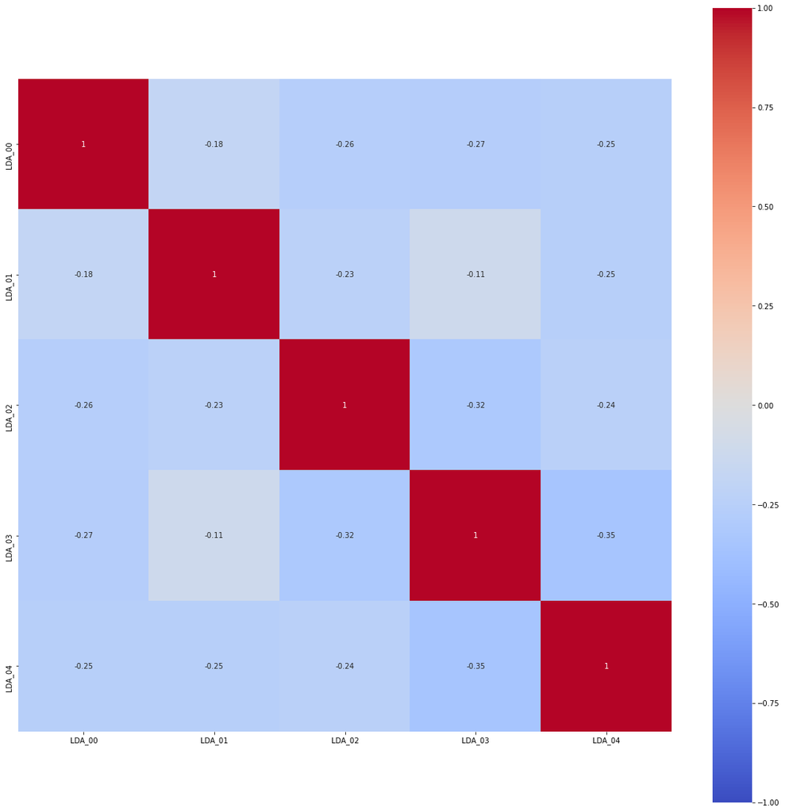

```python
corrplot(['LDA_00', 'LDA_01', 'LDA_02', 'LDA_03', 'LDA_04'])
```

There isn't enough evidence to claim that two topics are related. It isn't a surprise since the LDA method constructs topics that are independent. Nevertheless, we'll remove *LDA_00* as it's a linear combination of the rest :

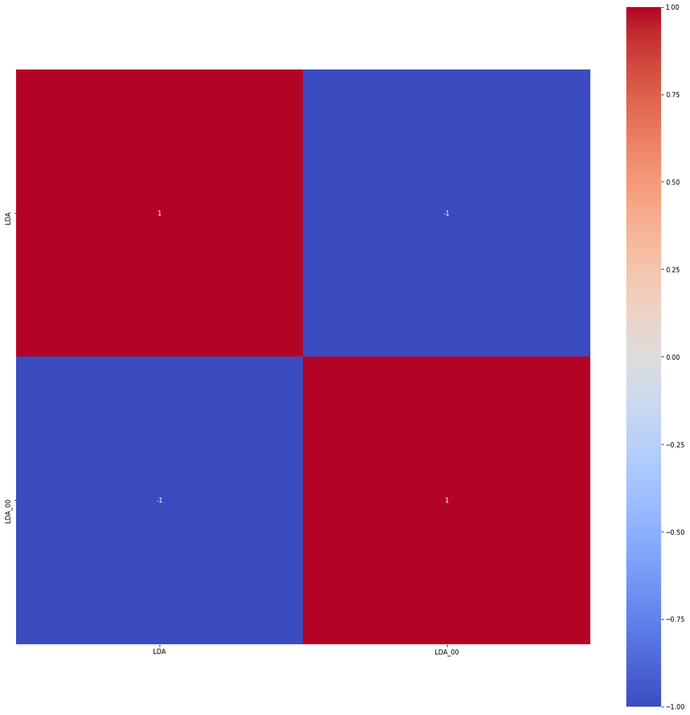

```python
data['LDA'] = data['LDA_01'] + data['LDA_02'] + data['LDA_03'] + data['LDA_04']
corrplot(['LDA', 'LDA_00'])
```

```python
data = data.drop(['LDA_00', 'LDA'], 1)
```

### Transforming the features *global*

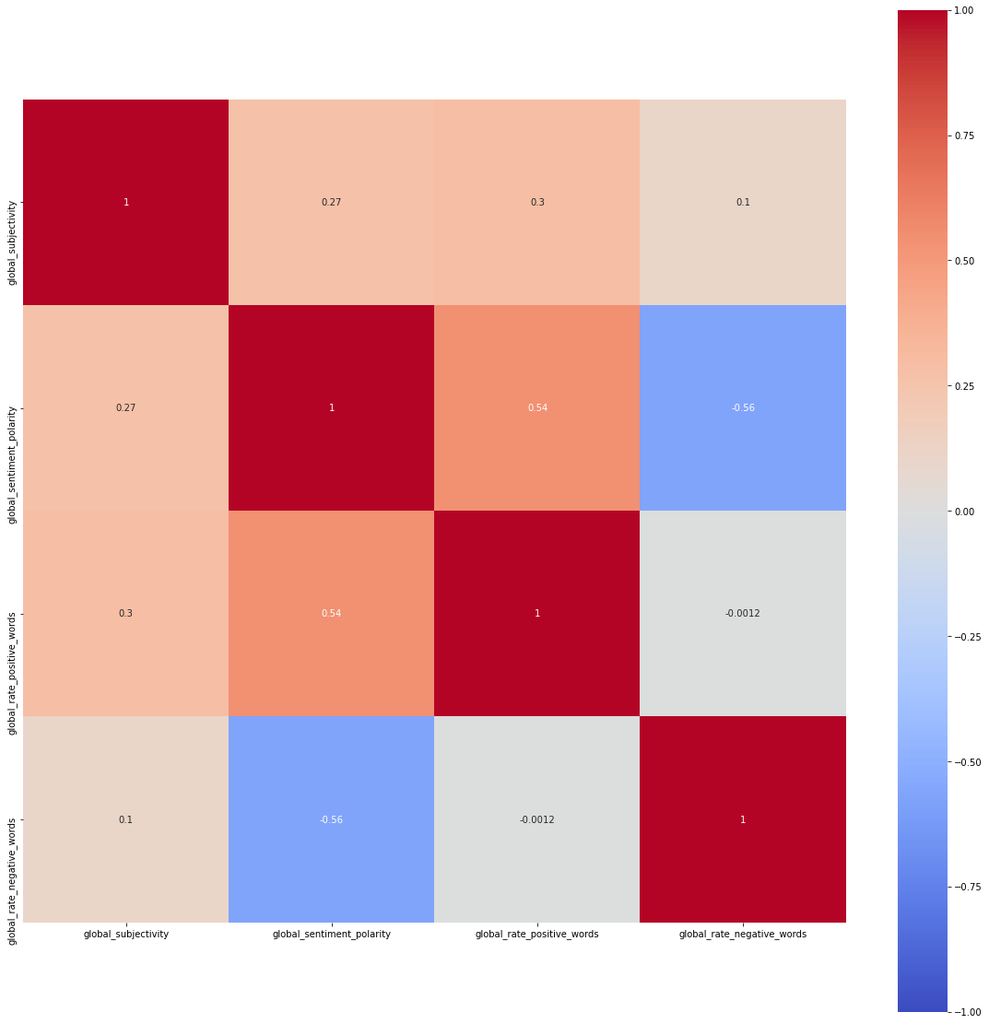

```python
corrplot(['global_subjectivity', 'global_sentiment_polarity', 'global_rate_positive_words', 'global_rate_negative_words'])
```

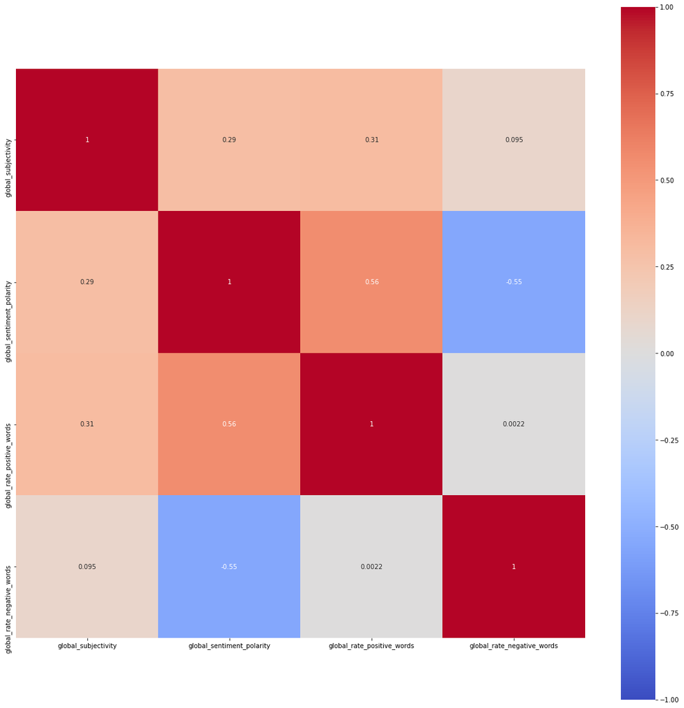

```python
corrplot(['global_subjectivity', 'global_sentiment_polarity', 'global_rate_positive_words', 'global_rate_negative_words'], 'spearman')
```

The *global_sentiment_polarity* is correlated to *global_rate_positive_words* and *global_rate_negative_words*. So, we decide to remove the former and keep the two latters.

```python
data = data.drop('global_sentiment_polarity', 1)
```

### Transforming the features *title*

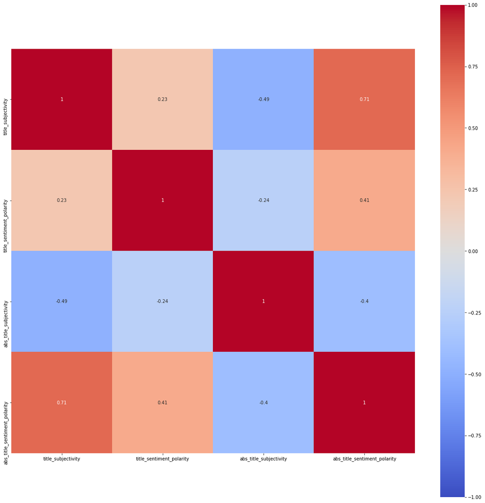

```python
corrplot(['title_subjectivity', 'title_sentiment_polarity', 'abs_title_subjectivity', 'abs_title_sentiment_polarity'])
```

For the same reasons, we remove the *abs_title_subjectivity* and *abs_title_sentiment_polarity*.

```python
data = data.drop(['abs_title_subjectivity', 'abs_title_sentiment_polarity'], 1)
```

### Transforming the features *polarity*

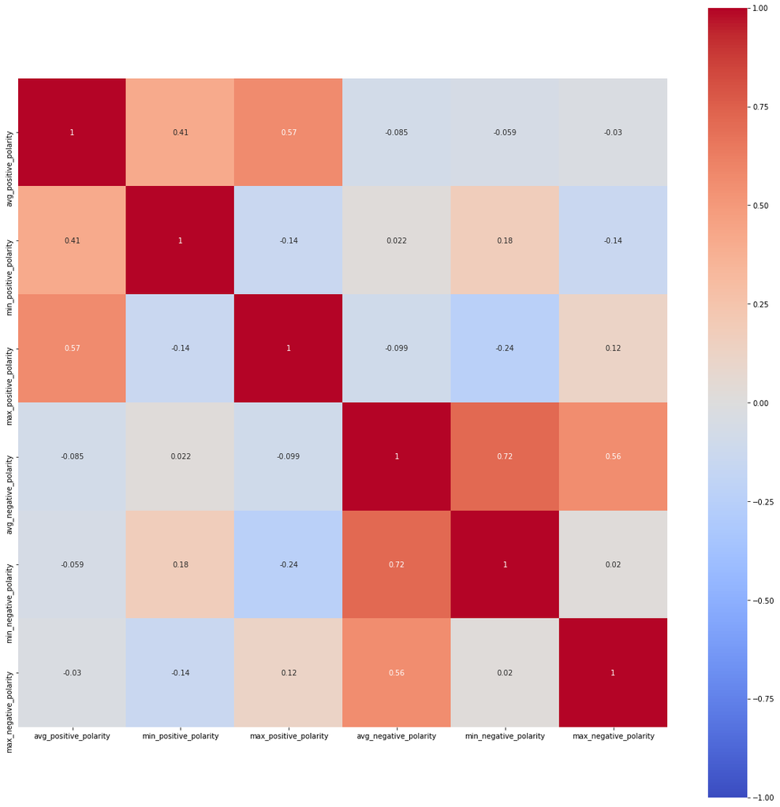

```python
corrplot(['avg_positive_polarity', 'min_positive_polarity', 'max_positive_polarity',
       'avg_negative_polarity', 'min_negative_polarity', 'max_negative_polarity'])
```

We remove *avg_positive_polarity* and *avg_negative_polarity*.

```python
data = data.drop(['avg_positive_polarity', 'avg_negative_polarity'], 1)
```

```python
import statsmodels.regression.linear_model as sm
import statsmodels.api as s
data1 = data[['num_imgs', 'num_videos', 'n_tokens_title']]
data1 = s.add_constant(data1)
data2 = data[['num_imgs', 'num_videos', 'n_tokens_title', 'data_channel_is_lifestyle',
       'data_channel_is_entertainment', 'data_channel_is_bus',
       'data_channel_is_socmed', 'data_channel_is_tech',
       'data_channel_is_world', 'weekday_is_monday', 'weekday_is_tuesday',
       'weekday_is_wednesday', 'weekday_is_thursday', 'weekday_is_friday',
       'weekday_is_saturday']]
data2 = s.add_constant(data2)
ols1 = sm.OLS(exog = data1, endog = data['shares']).fit()
#pred1= ols1.predict("rentrer le dataframe de l'utilisateur ici")
ols2 = sm.OLS(exog = data2, endog = data['shares']).fit()
#pred2= ols2.predict("rentrer le dataframe de l'utilisateur ici")

from sklearn.linear_model import LinearRegression
reg1 = LinearRegression().fit(data1, data['shares'])
reg2 = LinearRegression().fit(data2, data['shares'])
#pred1= reg1.predict("rentrer le dataframe de l'utilisateur ici")
#pred2= reg2.predict("rentrer le dataframe de l'utilisateur ici")
```

```python
ols1.summary2().tables[0][3][0]
```

```
'0.005'
```

# Regression models

Our problem is of the **regression** type. We shall compare the following models :  
**Forward selection with 10-fold cross-validation** on **transformed data** and **raw data**  
**Random Forest** on **transformed data** and **raw data**  
**Lasso regularization** on **transformed data** and **raw data**

## Metrics

We'll use two metrics for our prediction error :  
**Mean Absolute Error** : $MAE = \frac{1}{n}\sum^{n}_{k=1}|y_i - \hat{y}_i|$  
**Root Mean Square Error** : $RMSE = \sqrt{\frac{1}{n}\sum^{n}_{k=1}(y_i - \hat{y}_i)^2}$.  
These metrics are expressed in the same units as the target *shares*, their values should give more insight than other metrics such as the **Mean Square Error** as well as the **Mean Percentage Error**.  
Moreover, the **MAE** gives the easier metric to interpret but is less sensitive to outliers as opposed to the **RMSE**. We don't know the requirements of the prediction problem, thus, for safety measures we'll only keep the **MAE** for insight but not for feature selection.

```python
def MAE(pred, real) :
    return (pred - real).abs().mean()

def RMSE(pred, real) :
    return np.sqrt(((pred - real)**2).mean())
```

## **Forward selection with 10-fold cross-validation**

### Data splitting for 10-fold cross-validation

We'll use **cross-validation** by spliting the dataset in 10 sets of same length. By default, the **cross-validation score** is the $R^2$ of the model. Nevertheless, our aim is to return the best predictions, not the most linear model, especially since we're in no position to confirm such hypothesis. We chose the **CV score** to be the **arithmetic mean** $\frac{a_1+...+a_n}{n}$ where $a_k$ is the **RMSE** of the model where $set_k$ is the subset used of testing, while the rest is used for training. The **geometric mean** $\sqrt[\leftroot{-3}\uproot{3}n]{a_1\cdot...\cdot a_n}$ is better at representing the average of a sample whose elements are not independent, which is obviously our case thanks to the cross validation, but the **arithmetic mean** is the most sensitive to outliers, which will be the most valuable information in our minimization of the prediction error.

```python
import random
set1 = list(); set2 = list(); set3 = list();
set4 = list(); set5 = list(); set6 = list();
set7 = list(); set8 = list(); set9 = list();
set10 = list()
sets = data.copy().index.tolist()

while len(sets)//10 > 0 :
    set1.append(sets.pop(random.randint(0, len(sets)-1)))
    set2.append(sets.pop(random.randint(0, len(sets)-1)))
    set3.append(sets.pop(random.randint(0, len(sets)-1)))
    set4.append(sets.pop(random.randint(0, len(sets)-1)))
    set5.append(sets.pop(random.randint(0, len(sets)-1)))
    set6.append(sets.pop(random.randint(0, len(sets)-1)))
    set7.append(sets.pop(random.randint(0, len(sets)-1)))
    set8.append(sets.pop(random.randint(0, len(sets)-1)))
    set9.append(sets.pop(random.randint(0, len(sets)-1)))
    set10.append(sets.pop(random.randint(0, len(sets)-1)))
set1 = set1 + sets
```

### Linear Regression on transformed data

```python
import statsmodels.regression.linear_model as sm
import statsmodels.api as s
import time
features = data.drop('shares', axis = 1)
current_features = []
linearselection = pd.DataFrame(columns = ['feature_selected', 'rsquared_adj', 'rmse_train_score', 'rmse_test_score', 'mae_train_score',
            'mae_test_score'])
while len(features.columns) > 0 :
    t = time.time()
    for feature in features.columns :
        optimum = (None, None)

        set1train = data.loc[set2+set3+set4+set5+set6+set7+set8+set9+set10, current_features + [feature]]
        set1train = s.add_constant(set1train)
        set2train = data.loc[set1+set3+set4+set5+set6+set7+set8+set9+set10, current_features + [feature]]
        set2train = s.add_constant(set2train)
        set3train = data.loc[set2+set1+set4+set5+set6+set7+set8+set9+set10, current_features + [feature]]
        set3train = s.add_constant(set3train)
        set4train = data.loc[set2+set3+set1+set5+set6+set7+set8+set9+set10, current_features + [feature]]
        set4train = s.add_constant(set4train)
        set5train = data.loc[set2+set3+set4+set1+set6+set7+set8+set9+set10, current_features + [feature]]
        set5train = s.add_constant(set5train)
        set6train = data.loc[set2+set3+set4+set5+set1+set7+set8+set9+set10, current_features + [feature]]
        set6train = s.add_constant(set6train)
        set7train = data.loc[set2+set3+set4+set5+set6+set1+set8+set9+set10, current_features + [feature]]
        set7train = s.add_constant(set7train)
        set8train = data.loc[set2+set3+set4+set5+set6+set7+set1+set9+set10, current_features + [feature]]
        set8train = s.add_constant(set8train)
        set9train = data.loc[set2+set3+set4+set5+set6+set7+set8+set1+set10, current_features + [feature]]
        set9train = s.add_constant(set9train)
        set10train = data.loc[set2+set3+set4+set5+set6+set7+set8+set9+set1, current_features + [feature]]
        set10train = s.add_constant(set10train)

        set1trainvalidation = data.loc[set2+set3+set4+set5+set6+set7+set8+set9+set10, 'shares']
        set2trainvalidation = data.loc[set1+set3+set4+set5+set6+set7+set8+set9+set10, 'shares']
        set3trainvalidation = data.loc[set2+set1+set4+set5+set6+set7+set8+set9+set10, 'shares']
        set4trainvalidation = data.loc[set2+set3+set1+set5+set6+set7+set8+set9+set10, 'shares']
        set5trainvalidation = data.loc[set2+set3+set4+set1+set6+set7+set8+set9+set10, 'shares']
        set6trainvalidation = data.loc[set2+set3+set4+set5+set1+set7+set8+set9+set10, 'shares']
        set7trainvalidation = data.loc[set2+set3+set4+set5+set6+set1+set8+set9+set10, 'shares']
        set8trainvalidation = data.loc[set2+set3+set4+set5+set6+set7+set1+set9+set10, 'shares']
        set9trainvalidation = data.loc[set2+set3+set4+set5+set6+set7+set8+set1+set10, 'shares']
        set10trainvalidation = data.loc[set2+set3+set4+set5+set6+set7+set8+set9+set1, 'shares']

        set1test = data.loc[set1, current_features + [feature]]
        set1test = s.add_constant(set1test)
        set2test = data.loc[set2, current_features + [feature]]
        set2test = s.add_constant(set2test)
        set3test = data.loc[set3, current_features + [feature]]
        set3test = s.add_constant(set3test)
        set4test = data.loc[set4, current_features + [feature]]
        set4test = s.add_constant(set4test)
        set5test = data.loc[set5, current_features + [feature]]
        set5test = s.add_constant(set5test)
        set6test = data.loc[set6, current_features + [feature]]
        set6test = s.add_constant(set6test)
        set7test = data.loc[set7, current_features + [feature]]
        set7test = s.add_constant(set7test)
        set8test = data.loc[set8, current_features + [feature]]
        set8test = s.add_constant(set8test)
        set9test = data.loc[set9, current_features + [feature]]
        set9test = s.add_constant(set9test)
        set10test = data.loc[set10, current_features + [feature]]
        set10test = s.add_constant(set10test)

        set1testvalidation = data.loc[set1, 'shares']
        set2testvalidation = data.loc[set2, 'shares']
        set3testvalidation = data.loc[set3, 'shares']
        set4testvalidation = data.loc[set4, 'shares']
        set5testvalidation = data.loc[set5, 'shares']
        set6testvalidation = data.loc[set6, 'shares']
        set7testvalidation = data.loc[set7, 'shares']
        set8testvalidation = data.loc[set8, 'shares']
        set9testvalidation = data.loc[set9, 'shares']
        set10testvalidation = data.loc[set10, 'shares']

        ols1 = sm.OLS(exog = set1train, endog = set1trainvalidation).fit()
        ols1train = ols1.predict(set1train)
        ols1test = ols1.predict(set1test)
        ols2 = sm.OLS(exog = set2train, endog = set2trainvalidation).fit()
        ols2train = ols2.predict(set2train)
        ols2test = ols2.predict(set2test)
        ols3 = sm.OLS(exog = set3train, endog = set3trainvalidation).fit()
        ols3train = ols3.predict(set3train)
        ols3test = ols3.predict(set3test)
        ols4 = sm.OLS(exog = set4train, endog = set4trainvalidation).fit()
        ols4train = ols4.predict(set4train)
        ols4test = ols4.predict(set4test)
        ols5 = sm.OLS(exog = set5train, endog = set5trainvalidation).fit()
        ols5train = ols5.predict(set5train)
        ols5test = ols5.predict(set5test)
        ols6 = sm.OLS(exog = set6train, endog = set6trainvalidation).fit()
        ols6train = ols6.predict(set6train)
        ols6test = ols6.predict(set6test)
        ols7 = sm.OLS(exog = set7train, endog = set7trainvalidation).fit()
        ols7train = ols7.predict(set7train)
        ols7test = ols7.predict(set7test)
        ols8 = sm.OLS(exog = set8train, endog = set8trainvalidation).fit()
        ols8train = ols8.predict(set8train)
        ols8test = ols8.predict(set8test)
        ols9 = sm.OLS(exog = set9train, endog = set9trainvalidation).fit()
        ols9train = ols9.predict(set9train)
        ols9test = ols9.predict(set9test)
        ols10 = sm.OLS(exog = set10train, endog = set10trainvalidation).fit()
        ols10train = ols10.predict(set10train)
        ols10test = ols10.predict(set10test)

        rmsetrain = 0
        rmsetest = 0
        maetrain = 0
        maetest = 0
        rsquared = 0

        rmsetrain += (RMSE(ols1train, set1trainvalidation))
        rmsetest += (RMSE(ols1test, set1testvalidation))
        maetrain += (MAE(ols1train, set1trainvalidation))
        maetest += (MAE(ols1test, set1testvalidation))
        rsquared += float(ols1.summary2().tables[0][3][0])

        rmsetrain += (RMSE(ols2train, set2trainvalidation))
        rmsetest += (RMSE(ols2test, set2testvalidation))
        maetrain += (MAE(ols2train, set2trainvalidation))
        maetest += (MAE(ols2test, set2testvalidation))
        rsquared += float(ols2.summary2().tables[0][3][0])

        rmsetrain += (RMSE(ols3train, set3trainvalidation))
        rmsetest += (RMSE(ols3test, set3testvalidation))
        maetrain += (MAE(ols3train, set3trainvalidation))
        maetest += (MAE(ols3test, set3testvalidation))
        rsquared += float(ols3.summary2().tables[0][3][0])

        rmsetrain += (RMSE(ols4train, set4trainvalidation))
        rmsetest += (RMSE(ols4test, set4testvalidation))
        maetrain += (MAE(ols4train, set4trainvalidation))
        maetest += (MAE(ols4test, set4testvalidation))
        rsquared += float(ols4.summary2().tables[0][3][0])

        rmsetrain += (RMSE(ols5train, set5trainvalidation))
        rmsetest += (RMSE(ols5test, set5testvalidation))
        maetrain += (MAE(ols5train, set5trainvalidation))
        maetest += (MAE(ols5test, set5testvalidation))
        rsquared += float(ols5.summary2().tables[0][3][0])

        rmsetrain += (RMSE(ols6train, set6trainvalidation))
        rmsetest += (RMSE(ols6test, set6testvalidation))
        maetrain += (MAE(ols6train, set6trainvalidation))
        maetest += (MAE(ols6test, set6testvalidation))
        rsquared += float(ols6.summary2().tables[0][3][0])

        rmsetrain += (RMSE(ols7train, set7trainvalidation))
        rmsetest += (RMSE(ols7test, set7testvalidation))
        maetrain += (MAE(ols7train, set7trainvalidation))
        maetest += (MAE(ols7test, set7testvalidation))
        rsquared += float(ols7.summary2().tables[0][3][0])

        rmsetrain += (RMSE(ols8train, set8trainvalidation))
        rmsetest += (RMSE(ols8test, set8testvalidation))
        maetrain += (MAE(ols8train, set8trainvalidation))
        maetest += (MAE(ols8test, set8testvalidation))
        rsquared += float(ols8.summary2().tables[0][3][0])

        rmsetrain += (RMSE(ols9train, set9trainvalidation))
        rmsetest += (RMSE(ols9test, set9testvalidation))
        maetrain += (MAE(ols9train, set9trainvalidation))
        maetest += (MAE(ols9test, set9testvalidation))
        rsquared += float(ols9.summary2().tables[0][3][0])

        rmsetrain += (RMSE(ols10train, set10trainvalidation))
        rmsetest += (RMSE(ols10test, set10testvalidation))
        maetrain += (MAE(ols10train, set10trainvalidation))
        maetest += (MAE(ols10test, set10testvalidation))
        rsquared += float(ols10.summary2().tables[0][3][0])

        rmsetrainscore = rmsetrain / 10
        rmsetestscore = rmsetest / 10
        maetrainscore = maetrain / 10
        maetestscore = maetest / 10
        rsquared = rsquared / 10

        if optimum[1] == None :
            optimum = (feature, rmsetestscore)
        elif optimum[1] > rmsetestscore :
            optimum = (feature, rmsetestscore)

    features = features.drop(optimum[0], 1)
    current_features.append(optimum[0])
    linearselection = linearselection.append({'feature_selected' : optimum[0], 'rsquared_adj' : rsquared, 'rmse_train_score' : rmsetrainscore,
                                              'rmse_test_score' : rmsetestscore, 'mae_train_score' : maetrainscore,
                                              'mae_test_score' : maetestscore}, ignore_index = True)
    print(time.time() - t)
```

```
16.23103427886963
16.591506958007812
17.70838975906372
19.54827618598938
22.08528709411621
20.661906957626343
20.27823758125305
21.117619037628174
21.336445331573486
21.483511447906494
22.019802570343018
22.23102569580078
23.13430643081665
23.29781723022461
23.169326305389404
24.505688905715942
26.408987522125244
24.398160934448242
24.470391035079956
21.79914951324463
18.125293493270874
17.82237958908081
17.754039764404297
18.015316486358643
19.373469591140747
24.439019441604614
20.547917366027832
20.014795064926147
19.652491331100464
19.510982036590576
19.074463844299316
17.41985559463501
16.236026763916016
17.42735481262207
16.334046363830566
15.013003826141357
12.971813917160034
11.237753868103027
10.089154720306396
9.166254043579102
8.151487827301025
6.765258073806763
5.203289985656738
3.262071371078491
1.673311710357666
```

```python
linearselection
```

|  | feature_selected | rsquared_adj | rmse_train_score | rmse_test_score | mae_train_score | mae_test_score |
| --- | --- | --- | --- | --- | --- | --- |
| 0 | title_sentiment_polarity | 0.0000 | 11029.608385 | 10021.979349 | 3099.821271 | 3099.816090 |
| 1 | title_subjectivity | 0.0009 | 11027.097466 | 10019.256897 | 3096.929147 | 3096.989920 |
| 2 | max_negative_polarity | 0.0010 | 11024.696968 | 10016.503274 | 3096.457083 | 3096.571579 |
| 3 | min_negative_polarity | 0.0013 | 11021.320954 | 10012.494020 | 3094.070165 | 3094.414596 |
| 4 | max_positive_polarity | 0.0021 | 11018.761017 | 10010.686926 | 3090.972215 | 3091.448705 |
| 5 | min_positive_polarity | 0.0021 | 11018.364828 | 10010.076172 | 3090.658301 | 3091.223661 |
| 6 | rate_positive_words | 0.0021 | 11018.355318 | 10010.223731 | 3090.816271 | 3091.402739 |
| 7 | global_rate_negative_words | 0.0021 | 11017.821181 | 10009.378321 | 3088.980290 | 3089.588128 |
| 8 | global_rate_positive_words | 0.0021 | 11017.508801 | 10009.196924 | 3089.791992 | 3090.458920 |
| 9 | global_subjectivity | 0.0045 | 11004.314567 | 9993.731443 | 3077.965349 | 3079.110671 |
| 10 | LDA_04 | 0.0045 | 11003.793147 | 9993.572660 | 3080.420723 | 3081.662426 |
| 11 | LDA_03 | 0.0093 | 10978.374537 | 9964.933534 | 3052.441721 | 3053.830399 |
| 12 | LDA_02 | 0.0099 | 10974.103221 | 9960.603068 | 3042.945323 | 3044.346174 |
| 13 | LDA_01 | 0.0099 | 10973.198761 | 9959.828808 | 3039.486034 | 3041.117432 |
| 14 | weekday_is_saturday | 0.0104 | 10971.880265 | 9959.097001 | 3035.826952 | 3037.566524 |
| 15 | weekday_is_friday | 0.0102 | 10971.841647 | 9959.355630 | 3036.017002 | 3038.002342 |
| 16 | weekday_is_thursday | 0.0104 | 10971.457796 | 9959.177573 | 3035.961268 | 3038.210898 |
| 17 | weekday_is_wednesday | 0.0103 | 10971.399151 | 9959.590621 | 3035.733743 | 3038.275755 |
| 18 | weekday_is_tuesday | 0.0105 | 10970.760589 | 9958.783992 | 3033.694140 | 3036.217108 |
| 19 | weekday_is_monday | 0.0104 | 10970.754573 | 9958.877912 | 3033.524469 | 3036.098630 |
| 20 | self_reference_max_shares | 0.0117 | 10963.079491 | 9951.505452 | 3035.029448 | 3037.732121 |
| 21 | self_reference_min_shares | 0.0117 | 10962.718265 | 9951.344485 | 3034.962845 | 3037.982455 |
| 22 | kw_max_avg | 0.0144 | 10948.679973 | 9934.425363 | 3027.547141 | 3030.969689 |
| 23 | kw_min_avg | 0.0144 | 10948.485598 | 9934.224535 | 3027.479074 | 3030.903965 |
| 24 | kw_max_max | 0.0149 | 10944.065423 | 9929.015704 | 3016.342013 | 3019.510958 |
| 25 | kw_min_max | 0.0149 | 10944.041910 | 9929.204034 | 3016.444410 | 3019.600122 |
| 26 | kw_max_min | 0.0149 | 10944.021650 | 9929.625751 | 3016.537907 | 3019.933045 |
| 27 | kw_min_min | 0.0149 | 10943.849525 | 9929.847026 | 3015.912181 | 3019.500488 |
| 28 | data_channel_is_world | 0.0149 | 10943.803023 | 9930.196922 | 3015.447615 | 3019.157841 |
| 29 | data_channel_is_tech | 0.0148 | 10943.787425 | 9930.248687 | 3015.152238 | 3018.906376 |
| 30 | data_channel_is_socmed | 0.0148 | 10943.656391 | 9930.109704 | 3013.011652 | 3016.881586 |
| 31 | data_channel_is_bus | 0.0149 | 10943.324797 | 9930.305111 | 3011.221163 | 3015.299073 |
| 32 | data_channel_is_entertainment | 0.0167 | 10933.980980 | 9921.188021 | 2997.966524 | 3002.272450 |
| 33 | data_channel_is_lifestyle | 0.0170 | 10931.636535 | 9920.176010 | 2993.737623 | 2998.284527 |
| 34 | num_keywords | 0.0170 | 10931.534974 | 9920.422966 | 2993.467982 | 2998.049092 |
| 35 | average_token_length | 0.0170 | 10931.517326 | 9920.742415 | 2993.532871 | 2998.264931 |
| 36 | num_videos | 0.0174 | 10929.488777 | 9919.307872 | 2992.922379 | 2997.728187 |
| 37 | num_imgs | 0.0174 | 10928.507842 | 9918.653103 | 2989.881995 | 2994.894952 |
| 38 | num_self_hrefs | 0.0186 | 10921.679164 | 9911.456975 | 2992.304815 | 2996.797606 |
| 39 | num_hrefs | 0.0193 | 10918.418809 | 9908.193790 | 2990.282128 | 2994.963593 |
| 40 | n_non_stop_unique_tokens | 0.0192 | 10918.376843 | 9908.578364 | 2990.360780 | 2994.913791 |
| 41 | n_non_stop_words | 0.0198 | 10914.917597 | 9905.994355 | 2990.160279 | 2994.795446 |
| 42 | n_unique_tokens | 0.0199 | 10913.514524 | 9905.447222 | 2990.530578 | 2995.044891 |
| 43 | n_tokens_content | 0.0204 | 10911.567058 | 9904.451122 | 2991.826457 | 2996.626569 |
| 44 | n_tokens_title | 0.0205 | 10910.704291 | 9903.856956 | 2994.935639 | 2999.880997 |

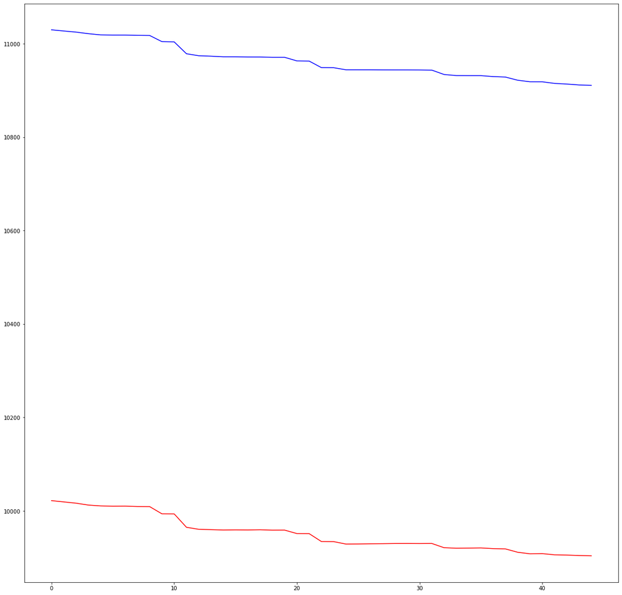

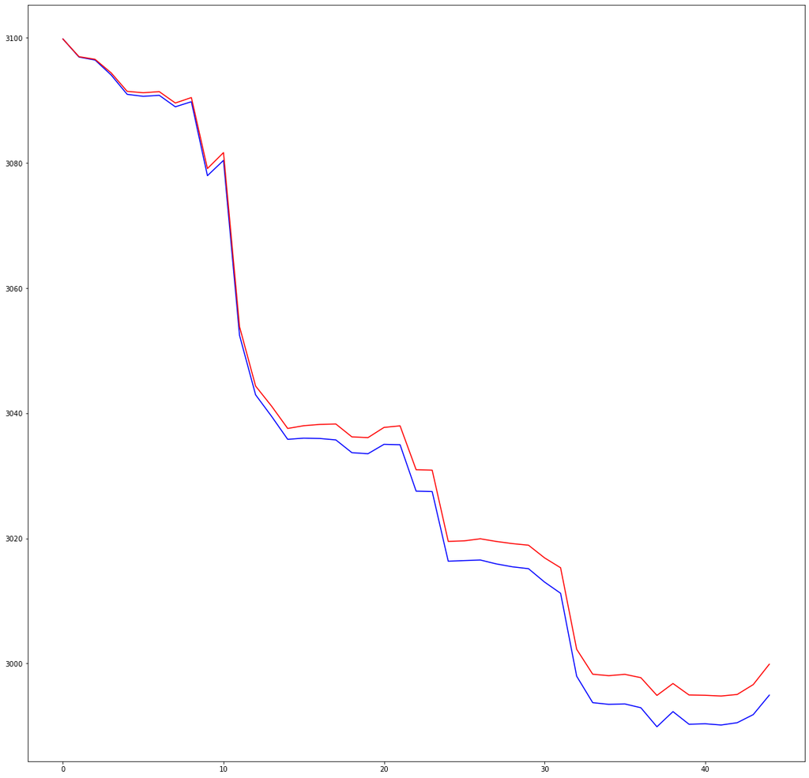

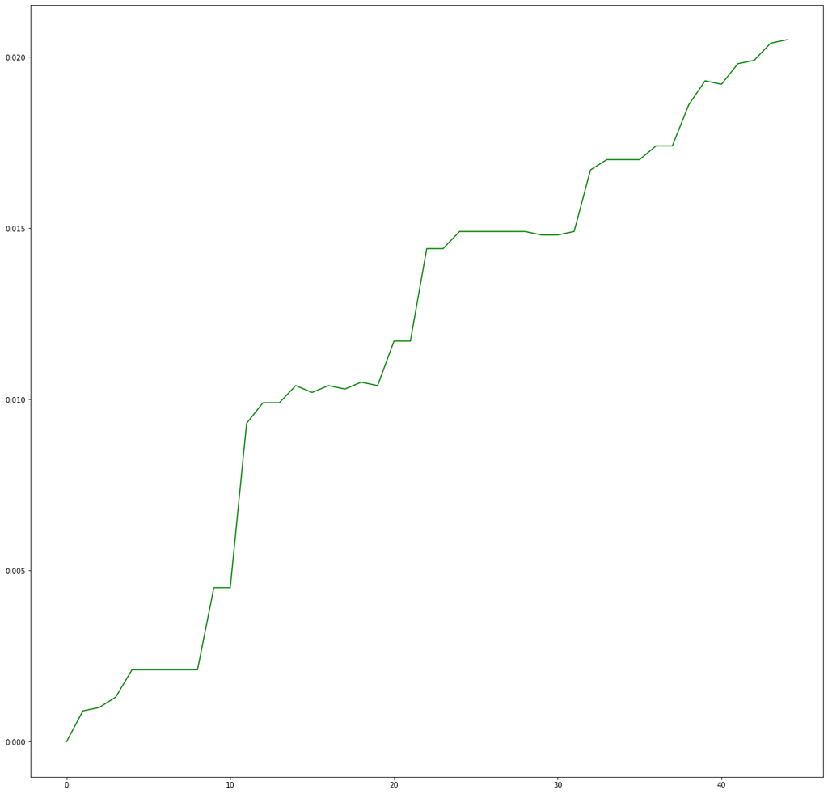

```python
plt.plot([i for i in range(len(linearselection))], linearselection['rmse_train_score'], 'b')
plt.plot([i for i in range(len(linearselection))], linearselection['rmse_test_score'], 'r')
plt.show()
plt.plot([i for i in range(len(linearselection))], linearselection['mae_train_score'], 'b')
plt.plot([i for i in range(len(linearselection))], linearselection['mae_test_score'], 'r')
plt.show()
plt.plot([i for i in range(len(linearselection))], linearselection['rsquared_adj'], 'g')
plt.show()
```

## **Random Forest**

```python
import time
from sklearn.ensemble import RandomForestRegressor
from sklearn.model_selection import train_test_split
datatrain, datatest, sharestrain, sharestest = train_test_split(data.drop('shares', 1), data['shares'], train_size = 0.67)

forestselection = pd.DataFrame(columns = ['trees', 'rmse_auto_train', 'rmse_auto_test', 'autoscore', 'rmse_sqrt_train',
            'rmse_sqrt_test', 'sqrtscore', 'rmse_log_train', 'rmse_log_test', 'logscore'])

for t in range(1, len(data.columns)) :
    timer = time.time()

    treeauto = RandomForestRegressor(n_estimators = t, criterion = 'mse', max_features = 'auto')
    treeauto.fit(datatrain, sharestrain)
    rmseautotrain = RMSE(treeauto.predict(datatrain), sharestrain)
    rmseautotest = RMSE(treeauto.predict(datatest), sharestest)
    autoscore = treeauto.score(datatest, sharestest)

    treesqrt = RandomForestRegressor(n_estimators = t, criterion = 'mse', max_features = 'sqrt')
    treesqrt.fit(datatrain, sharestrain)
    rmsesqrttrain = RMSE(treesqrt.predict(datatrain), sharestrain)
    rmsesqrttest = RMSE(treesqrt.predict(datatest), sharestest)
    sqrtscore = treesqrt.score(datatest, sharestest)

    treelog = RandomForestRegressor(n_estimators = t, criterion = 'mse', max_features = 'log2')
    treelog.fit(datatrain, sharestrain)
    rmselogtrain = RMSE(treelog.predict(datatrain), sharestrain)
    rmselogtest = RMSE(treelog.predict(datatest), sharestest)
    logscore = treelog.score(datatest, sharestest)

    forestselection = forestselection.append({'trees' : t, 'rmse_auto_train' : rmseautotrain, 'rmse_auto_test' : rmseautotest, 'autoscore' : autoscore,
                                             'rmse_sqrt_train' : rmsesqrttrain, 'rmse_sqrt_test' : rmsesqrttest, 'sqrtscore' : sqrtscore,
                                             'rmse_log_train' : rmselogtrain, 'rmse_log_test' : rmselogtest, 'logscore' : logscore}, ignore_index = True)

    print(str(t), str(time.time() - timer))

forestselection
```

```
1 1.0698928833007812
2 1.8922703266143799
3 2.8239593505859375
4 3.7149994373321533
5 4.686361789703369
6 5.455584287643433
7 6.672672748565674
8 7.592477083206177
9 9.122093439102173
10 9.79667615890503
11 10.256826162338257
12 11.040406465530396
13 12.007095336914062
14 12.903761386871338
15 14.529617547988892
```

[output cut: 30 more lines]

|  | trees | rmse_auto_train | rmse_auto_test | autoscore | rmse_sqrt_train | rmse_sqrt_test | sqrtscore | rmse_log_train | rmse_log_test | logscore |
| --- | --- | --- | --- | --- | --- | --- | --- | --- | --- | --- |
| 0 | 1.0 | 7715.773362 | 15843.270148 | -0.461525 | 9028.108820 | 15951.842976 | -0.481625 | 7823.467407 | 15253.207978 | -0.354687 |
| 1 | 2.0 | 6584.866674 | 14641.656920 | -0.248237 | 5508.140628 | 14526.382010 | -0.228659 | 7877.742369 | 16100.043747 | -0.509283 |
| 2 | 3.0 | 5776.616032 | 14454.135837 | -0.216468 | 6896.710827 | 14695.564346 | -0.257445 | 5266.860898 | 14212.441337 | -0.176126 |
| 3 | 4.0 | 6268.362104 | 14478.588906 | -0.220588 | 4849.098427 | 14124.278597 | -0.161580 | 5785.430012 | 13801.331628 | -0.109069 |
| 4 | 5.0 | 4698.275911 | 13769.117182 | -0.103897 | 5052.534741 | 13766.953822 | -0.103550 | 4981.580448 | 13816.734258 | -0.111546 |
| 5 | 6.0 | 4571.821341 | 13758.358815 | -0.102173 | 4663.853902 | 14087.527586 | -0.155543 | 5034.731123 | 13564.030263 | -0.071258 |
| 6 | 7.0 | 4503.462028 | 13619.549147 | -0.080045 | 4897.603328 | 13821.191722 | -0.112263 | 4459.731359 | 13393.696267 | -0.044521 |
| 7 | 8.0 | 5088.120581 | 13701.262466 | -0.093044 | 4543.647743 | 13734.439260 | -0.098344 | 4468.378178 | 13738.015803 | -0.098916 |
| 8 | 9.0 | 4470.463088 | 13620.743460 | -0.080235 | 4321.962912 | 13391.622731 | -0.044198 | 4757.472390 | 13404.858377 | -0.046263 |
| 9 | 10.0 | 4615.658969 | 13428.105292 | -0.049895 | 4219.302620 | 13359.976989 | -0.039269 | 4147.529181 | 13379.443826 | -0.042300 |
| 10 | 11.0 | 3992.361738 | 13601.486677 | -0.077182 | 4331.600010 | 13390.176165 | -0.043972 | 3929.932398 | 13386.146079 | -0.043344 |
| 11 | 12.0 | 4604.796671 | 13463.053744 | -0.055367 | 4077.657896 | 13373.475812 | -0.041370 | 3829.870754 | 13329.776281 | -0.034575 |
| 12 | 13.0 | 4516.108508 | 13573.000947 | -0.072675 | 3810.356154 | 13392.618462 | -0.044353 | 4293.107248 | 13320.617455 | -0.033154 |
| 13 | 14.0 | 4335.656020 | 13425.819069 | -0.049538 | 3961.023160 | 13301.812676 | -0.030239 | 3962.963738 | 13307.663843 | -0.031146 |
| 14 | 15.0 | 3928.785887 | 13509.162622 | -0.062609 | 3958.011424 | 13275.252714 | -0.026129 | 3746.656016 | 13255.686395 | -0.023107 |
| 15 | 16.0 | 4202.284668 | 13405.144966 | -0.046308 | 3839.299629 | 13290.131834 | -0.028431 | 4481.308612 | 13232.411816 | -0.019517 |
| 16 | 17.0 | 4621.318691 | 13643.416869 | -0.083834 | 4109.042906 | 13274.609938 | -0.026030 | 4386.583528 | 13243.078484 | -0.021161 |
| 17 | 18.0 | 3900.419411 | 13372.661660 | -0.041243 | 4373.996968 | 13281.594809 | -0.027110 | 3796.210355 | 13244.799023 | -0.021427 |
| 18 | 19.0 | 5185.702292 | 13271.577959 | -0.025561 | 3995.620533 | 13249.238091 | -0.022111 | 3698.628385 | 13238.749171 | -0.020494 |
| 19 | 20.0 | 4273.147560 | 13471.339427 | -0.056667 | 3926.265157 | 13228.096683 | -0.018852 | 4041.189140 | 13233.471877 | -0.019680 |
| 20 | 21.0 | 3782.965447 | 13310.206517 | -0.031540 | 3895.474305 | 13279.528793 | -0.026790 | 3605.505509 | 13233.578051 | -0.019697 |
| 21 | 22.0 | 4187.488553 | 13339.674834 | -0.036113 | 4129.955318 | 13297.563923 | -0.029581 | 4077.288350 | 13214.839186 | -0.016811 |
| 22 | 23.0 | 4097.448279 | 13343.056977 | -0.036638 | 4279.370253 | 13190.619237 | -0.013087 | 3753.287690 | 13206.302905 | -0.015498 |
| 23 | 24.0 | 3996.900309 | 13291.958836 | -0.028713 | 3928.405849 | 13250.005016 | -0.022230 | 3880.293344 | 13229.836097 | -0.019120 |
| 24 | 25.0 | 4581.626850 | 13304.289785 | -0.030623 | 4094.703109 | 13213.921121 | -0.016670 | 4244.501000 | 13206.327726 | -0.015502 |
| 25 | 26.0 | 4126.117241 | 13316.157090 | -0.032462 | 4112.267125 | 13153.332093 | -0.007368 | 3532.312432 | 13189.002972 | -0.012839 |
| 26 | 27.0 | 4142.387473 | 13356.693764 | -0.038758 | 4101.749421 | 13135.589870 | -0.004652 | 4054.683620 | 13190.066549 | -0.013002 |
| 27 | 28.0 | 4511.357108 | 13258.317823 | -0.023513 | 3783.391687 | 13164.352978 | -0.009057 | 4271.432477 | 13149.593701 | -0.006795 |
| 28 | 29.0 | 4281.570698 | 13306.846236 | -0.031019 | 4025.218972 | 13128.618874 | -0.003586 | 3817.530648 | 13158.674017 | -0.008186 |
| 29 | 30.0 | 3688.418528 | 13279.818777 | -0.026835 | 4032.288235 | 13160.489003 | -0.008464 | 4512.145917 | 13136.219664 | -0.004748 |
| 30 | 31.0 | 3730.858190 | 13395.544908 | -0.044810 | 3820.480679 | 13185.248879 | -0.012262 | 3866.892243 | 13146.765368 | -0.006362 |
| 31 | 32.0 | 3812.814889 | 13336.156034 | -0.035566 | 4030.657318 | 13149.186652 | -0.006733 | 3892.703870 | 13163.153371 | -0.008873 |
| 32 | 33.0 | 3861.725499 | 13360.058742 | -0.039281 | 4026.412875 | 13187.508484 | -0.012609 | 3589.897314 | 13155.725029 | -0.007734 |
| 33 | 34.0 | 3956.014339 | 13227.988466 | -0.018835 | 3505.568041 | 13120.799926 | -0.002391 | 3996.970274 | 13135.481575 | -0.004635 |
| 34 | 35.0 | 3876.388358 | 13236.185917 | -0.020099 | 3818.237506 | 13147.246928 | -0.006436 | 4000.340689 | 13152.789178 | -0.007285 |
| 35 | 36.0 | 3826.442916 | 13228.678853 | -0.018942 | 3770.413296 | 13137.697232 | -0.004974 | 3812.639819 | 13149.428139 | -0.006770 |
| 36 | 37.0 | 4098.598654 | 13303.489514 | -0.030499 | 4053.763924 | 13096.107963 | 0.001378 | 4140.739564 | 13143.841115 | -0.005914 |
| 37 | 38.0 | 4284.501917 | 13284.689797 | -0.027589 | 4269.166353 | 13141.125214 | -0.005499 | 3724.811241 | 13135.844222 | -0.004691 |
| 38 | 39.0 | 3873.600688 | 13297.299045 | -0.029540 | 3585.790854 | 13146.988372 | -0.006396 | 3908.787972 | 13142.183494 | -0.005661 |
| 39 | 40.0 | 3835.016832 | 13277.640160 | -0.026498 | 3888.868514 | 13127.978149 | -0.003488 | 3787.986849 | 13149.387081 | -0.006764 |
| 40 | 41.0 | 3941.186639 | 13291.432243 | -0.028632 | 4262.137884 | 13117.664253 | -0.001912 | 3571.750304 | 13077.804309 | 0.004168 |
| 41 | 42.0 | 3884.716620 | 13282.223101 | -0.027207 | 3758.999936 | 13133.152643 | -0.004279 | 3833.569468 | 13126.699486 | -0.003292 |
| 42 | 43.0 | 3636.821967 | 13311.713750 | -0.031774 | 3809.634616 | 13155.799470 | -0.007746 | 4112.293122 | 13118.802293 | -0.002086 |
| 43 | 44.0 | 3898.470478 | 13275.327877 | -0.026141 | 3567.315550 | 13145.165503 | -0.006117 | 3540.661335 | 13131.547263 | -0.004034 |
| 44 | 45.0 | 4140.134024 | 13213.802822 | -0.016651 | 4257.713662 | 13096.186441 | 0.001366 | 3803.678693 | 13082.899905 | 0.003392 |

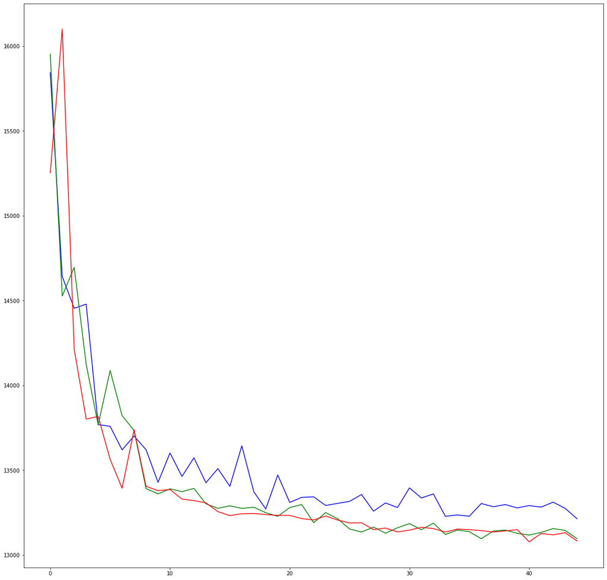

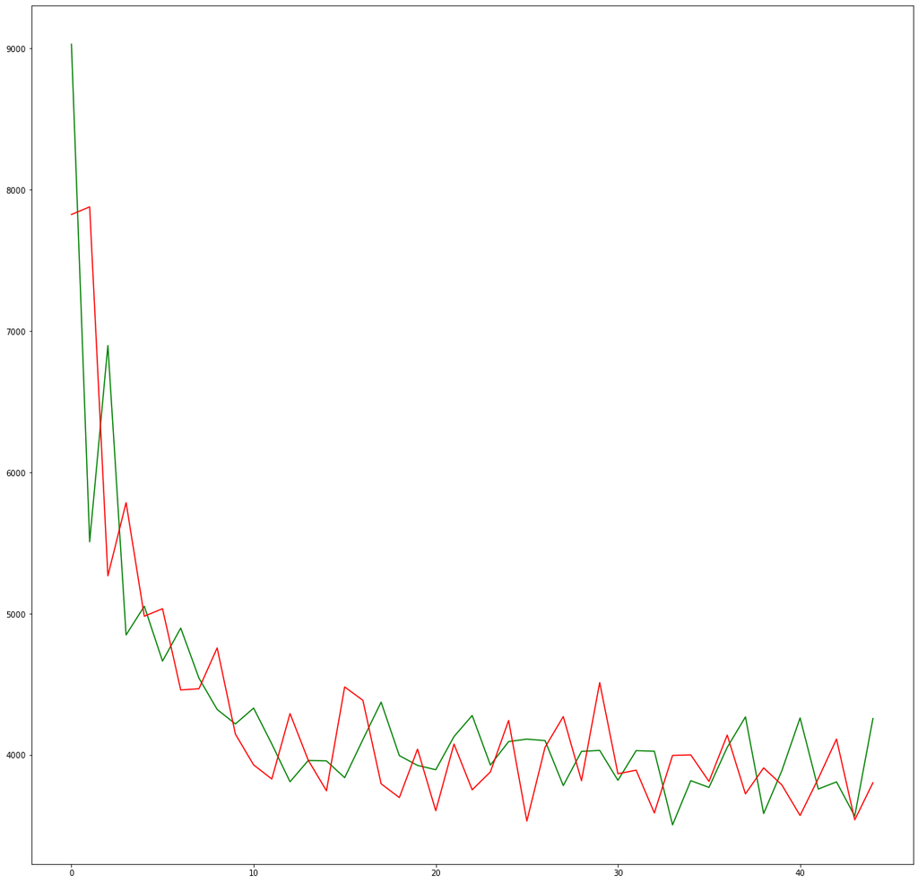

```python
plt.plot([i for i in range(len(forestselection))], forestselection['rmse_auto_test'], 'b')
plt.plot([i for i in range(len(forestselection))], forestselection['rmse_sqrt_test'], 'g')
plt.plot([i for i in range(len(forestselection))], forestselection['rmse_log_test'], 'r')
plt.show()
plt.plot([i for i in range(len(forestselection))], forestselection['rmse_sqrt_train'], 'g')
plt.plot([i for i in range(len(forestselection))], forestselection['rmse_log_train'], 'r')
plt.show()
```

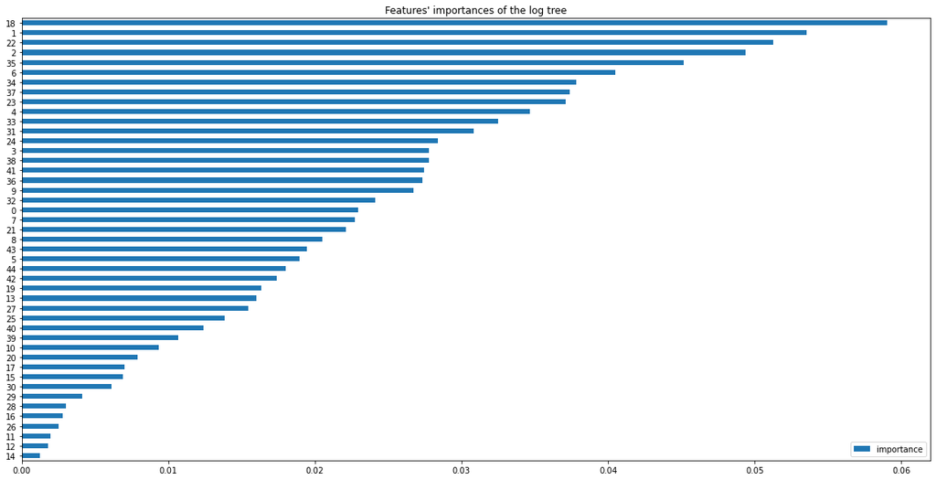

```python
names_and_feature_imp = pd.DataFrame({'names': data.drop('shares', 1).columns,
                                     'importance': treelog.feature_importances_})
names_and_feature_imp.sort_values(["importance"], ascending=True, inplace=True)
names_and_feature_imp.plot(kind='barh', title="Features' importances of the log tree",figsize=(20,10))
```

## **LinearRegression**

```python
from sklearn.ensemble import RandomForestRegressor
regr = LinearRegression()

regr.fit(datatrain, sharestrain)

s_pred = regr.predict(datatest)


print('Coefficients: \n', regr.coef_)
```

```
Coefficients:
 [  120.84726213  2117.02046751  2928.46003747 -5906.40527215
 -3280.42259637   584.02340882 -1023.50461024    72.78834462
   342.1737301   -251.66186122    45.91461272 -1043.7869629
 -1748.34323235 -1564.66875616  -766.91608199  -714.03345883
  -890.63658651   -21.57441559    15.88234142    52.51523107
  -334.08886781   -71.97026593  1093.11067204   -20.39392475
   219.75254272   127.28963997  -467.90885924  -108.08509883
  -444.56876275  -316.10044995   182.50924938  -771.31270151
 -2298.20672665  -748.98201408 -1069.8243677   2774.69571584
 -9275.27992661 -3878.28142731  -600.07938247 -2965.43839659
   115.84813135  -418.86550371  -624.17226263    45.27160914
   431.5087364 ]
```

## **Decision Tree**

```python
from sklearn.tree import DecisionTreeRegressor
regressor = DecisionTreeRegressor()
regressor.fit(datatrain,sharestrain)

y_pred = regressor.predict(datatest)

print("RMSE: " + str(round((RMSE(sharestest,y_pred)),2)))
```

```
RMSE: 17505.55
```

# Flask regression

```python
dataapi =  data[['n_tokens_title', 'num_imgs', 'num_videos']]

yy = data['shares']

dataapi =  data[['n_tokens_title', 'num_imgs', 'num_videos']]

yy = data['shares']

from sklearn.model_selection import train_test_split

Xtrain, Xtest, Ytrain, Ytest = train_test_split(dataapi, yy, train_size=0.8)

from sklearn.linear_model import LinearRegression
from sklearn.metrics import mean_squared_error, r2_score
regr = LinearRegression()

model_saved1 = regr.fit(Xtrain, Ytrain)

s_pred = regr.predict(Xtest)


print('Coefficients: \n', regr.coef_)

print("Mean squared error:", mean_squared_error(Ytest, s_pred))

print('Variance score:', r2_score(Ytest, s_pred))

!pip install joblib
import joblib
joblib.dump(model_saved1, "./model_saved1")
```